# Assignment 08

## Homework 8

#### Due Tuesday, November 16, 11:59 PM CT

Problems 1-3 are based on the random variable $X \sim \text{Binomial}(60, 0.4)$.

### Problem 1

### A

Calculate and report the mean and standard deviation of the distribution.

```r
n = 60
p = 0.4
mu = n*p
mu
```

```
## [1] 24
```

```r
sigma = sqrt(mu*(1-p))
sigma
```

```
## [1] 3.794733
```

### B

Calculate and report $\mathsf{P}(X = 25)$

```r
p_val1 = dbinom(25, 60, 0.4)
p_val1
```

```
## [1] 0.1004824
```

### C

Calculate and report $\mathsf{P}(X >= 25)$

```r
p_val2 = sum(dbinom(25:1000, 60, 0.4))
p_val2
```

```
## [1] 0.4442244
```

### D

Create a graph which displays the binomial distribution with bars for $x \ge 25$ colored in a different color from the rest to help visualize your answer to **C**.

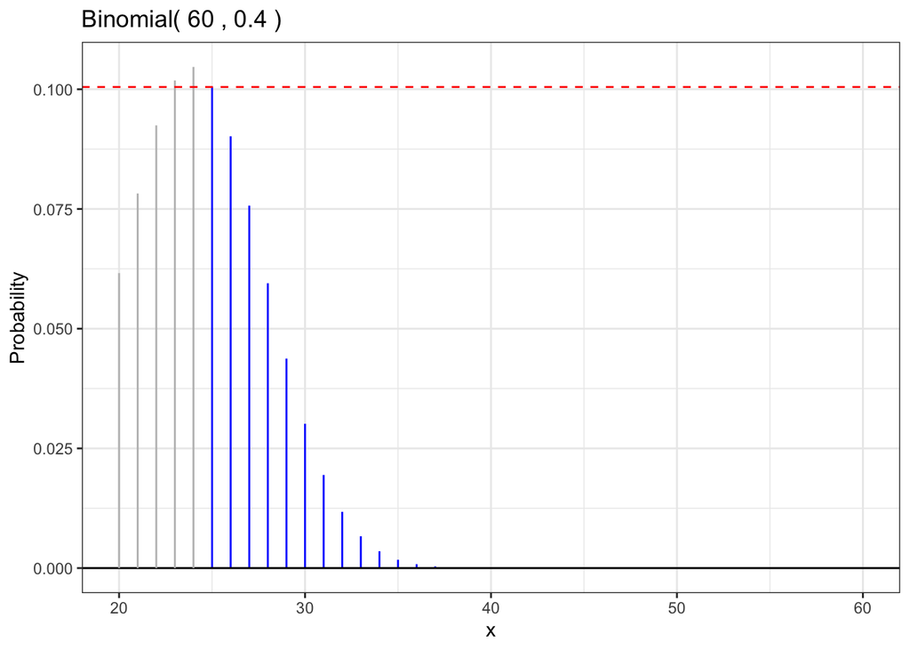

```r
gbinom(60, 0.4, a = 25, b = 60) +
  geom_binom_density(60, 0.4, a = 20, b = 24, color = "gray") +
  geom_hline(yintercept = dbinom(25, 60, 0.4), color = "red", linetype = "dashed") +
  theme_bw()
```

### Problem 2

What is the probability that $X$ is within one, two, and three standard deviations of the mean? Round each probability to four decimal places.

```r
sds = round(mu + c(-3,-2,-1,0,1,2,3)*sigma)
sds
```

```
## [1] 13 16 20 24 28 32 35
```

```r
p_val3 = sum(dbinom(21 : 27, 60, 0.4))
round(p_val3, 4)
```

```
## [1] 0.6436
```

```r
p_val4 = sum(dbinom(17 : 31, 60, 0.4))
round(p_val4, 4)
```

```
## [1] 0.9529
```

```r
p_val5 = sum(dbinom(13 : 35, 60, 0.4))
round(p_val5, 4)
```

```
## [1] 0.9978
```

### Problem 3

Draw a graph of this binomial distribution with vertical lines with different line types at the end points of the intervals 1, 2, and 3 sigma from the mean.

- solid for $\mu \pm \sigma$
- dashed for $\mu \pm 2\sigma$
- dotted for $\mu \pm 3\sigma$

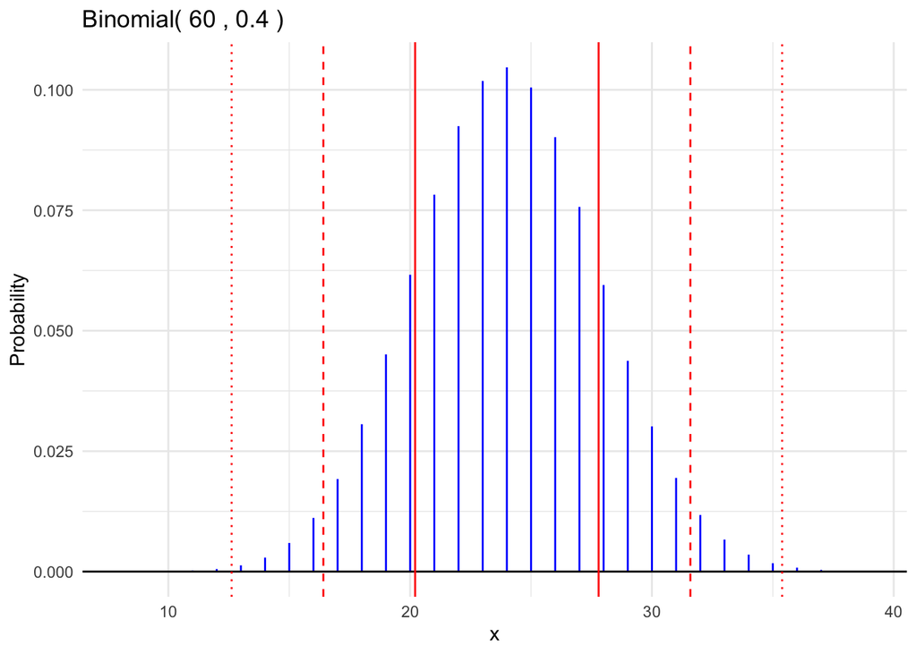

```r
gbinom(60, 0.4, scale = TRUE) +
  geom_vline(xintercept = mu + c(-1,1)*sigma,
             color = "red") +
  geom_vline(xintercept = mu + c(-2,2)*sigma,
             color = "red", linetype = "dashed") +
   geom_vline(xintercept = mu + c(-3,3)*sigma,
             color = "red", linetype = "dotted") +
  theme_minimal()
```

### Problem 4

### A

Create a tibble where each row corresponds to a binomial distribution with the following columns:

- `n` for $n = 1000,1001, \ldots, 10,000$
- `p` equal to 0.9 for each row
- `mu` equal to the mean
- `sigma` equal to the standard deviation
- `q.975` equal to the 0.975 quantile of the distribution
- `z = (q.975 - mu)/sigma`, the standardized z-score of the quantile
- `prob` equal to $\mathsf{P}(X \ge q.975)$, a right-tail probability for the distribution in each row

Display all columns and the rows of this table for which $n$ is a multiple of 1000.

```r
tib = tibble(n = 1000:10000,
             p = 0.9,
             mu = n * p,
             sigma = sqrt(mu*(1-p)),
             q.975 = qbinom(0.975, n, p),
             z = (q.975 - mu)/sigma,
             prob = 1 - pbinom(q.975 - 1, n, p))

prob = tib %>%
  filter((n %% 1000) == 0)

print(prob, width = Inf, n = Inf)
```

```
## # A tibble: 10 × 7
##        n     p    mu sigma q.975     z   prob
##    <int> <dbl> <dbl> <dbl> <dbl> <dbl>  <dbl>
##  1  1000   0.9   900  9.49   918  1.90 0.0299
##  2  2000   0.9  1800 13.4   1826  1.94 0.0269
##  3  3000   0.9  2700 16.4   2732  1.95 0.0262
##  4  4000   0.9  3600 19.0   3637  1.95 0.0260
##  5  5000   0.9  4500 21.2   4541  1.93 0.0270
##  6  6000   0.9  5400 23.2   5445  1.94 0.0267
##  7  7000   0.9  6300 25.1   6349  1.95 0.0257
##  8  8000   0.9  7200 26.8   7252  1.94 0.0266
##  9  9000   0.9  8100 28.5   8155  1.93 0.0269
## 10 10000   0.9  9000 30     9058  1.93 0.0269
```

### B

Use a line plot to show the relationship between $n$ on the x axis and $z$ on the y axis. Add a smooth curve to highlight the trend. Describe the pattern you see.

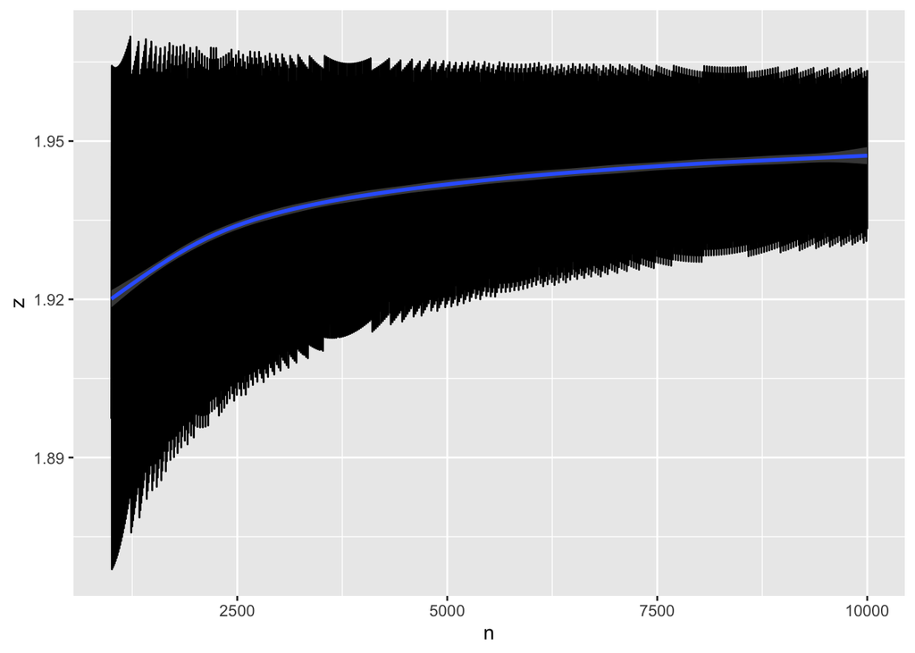

```r
ggplot(tib, aes(x = n, y = z)) +
  geom_line() +
  geom_smooth()
```

The smooth curve begins with an approximate logarithmic growth pattern, and later follows a mostly linear pattern with the data oscillating less as n increases

### C

What is the average of the values of $z$ for $n > 9000$?

```r
avg_val = tib %>%
  filter(n > 9000) %>%
  summarize(avg_z = mean(z))

avg_val
```

```
## # A tibble: 1 × 1
##   avg_z
##   <dbl>
## 1  1.95
```

### D

Plot the right tail probability `prob` on y axis versus `n` on the x axis.

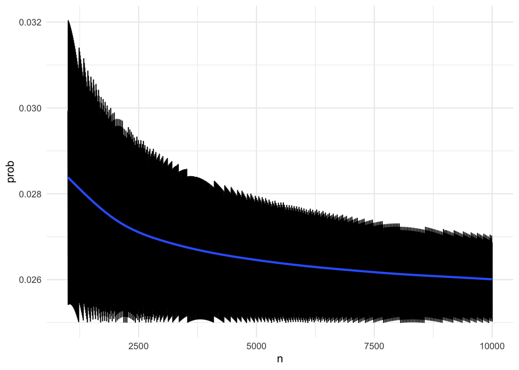

```r
ggplot(tib, aes(x = n, y = prob)) +
  geom_line() +
  geom_smooth(se = FALSE) +
  theme_minimal()
```

### E

What is the average of the values of `prob` for $n > 9000$?

```r
avg_val2 = tib %>%
  filter(n > 9000) %>%
  summarize(avg_prob = mean(prob))

avg_val2
```

```
## # A tibble: 1 × 1
##   avg_prob
##      <dbl>
## 1   0.0260
```

### Problem 5

### A

What is the 0.975 quantile of the standard normal distribution?

```r
qnorm(0.975, 0, 1)
```

```
## [1] 1.959964
```

### B

What is the area to the right of this quantile?

```r
(1 - pnorm(1.96)) /2
```

```
## [1] 0.01249895
```

### Problem 6

For the $\text{N}(500,100)$ distribution, find values $a$ and $b$ such that $a < b$, the area between $a$ and $b$ under the normal density is equal to 0.6, and $a$ and $b$ are equally distant from $\mu = 500$.

```r
mu = 500
sd = 100
# p = 0.6   Because we want the middle 0.6, do double tail qnorm() to find a and b
p1 = 0.2
p2 = 0.8


a = qnorm(0.2, 500, 100)
a
```

```
## [1] 415.8379
```

```r
b = qnorm(0.8, 500, 100)
b
```

```
## [1] 584.1621
```

```r
# Double check to see if area is 0.6
pnorm(b, 500, 100) - pnorm(a, 500, 100)
```

```
## [1] 0.6
```

### Problem 7

Graph the $\text{N}(500,100)$ distribution and shade the area between $a$ and $b$ from the previous problem.

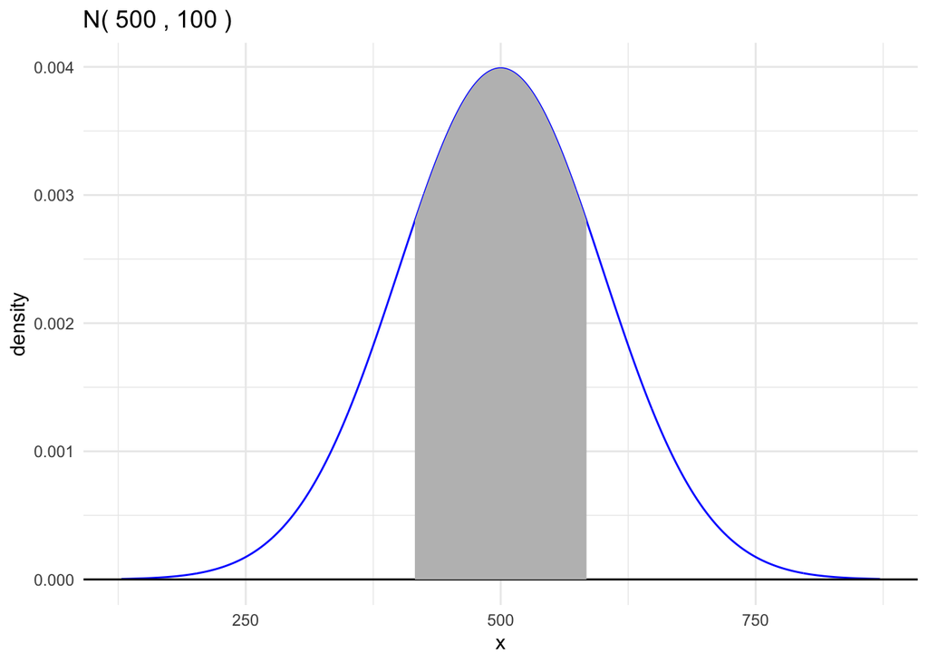

```r
gnorm(500, 100) +
  geom_norm_fill(500, 100, a, b, fill = "grey") +
  theme_minimal()
```